# Let’s use this year to fix K-Ville

Charlie Gelman

January 25, 2021

### A Need for a Change

There will not be any fans in Cameron Indoor Stadium this year. We all know that this is not the same Cameron we’re used to. However, the Cameron we’re used to is not the Cameron that Coach K is used to. In the surprise meeting following the “Jeff Capel, sit with us” chant, Coach K told us that Cameron was at its best when he felt he was entering “Club Cameron.” He wanted to feel like he was going to the club whenever he was walking onto the court named after him. But, he hasn’t felt that way in years.

Don’t get me wrong- the Cameron Crazies are still probably the greatest student section in college basketball. I believe Cameron isn’t as Crazie anymore partially because of the K-Ville leadership: the Line Monitors. The leaders of the Cameron Crazies should be the craziest of all fans, but they’re not.

If we want to get back to Club Cameron status, we need to be a cohesive student section. I’ve seen countless times when Line Monitors do not want to follow tenters’ chants. I’ve also seen countless times when tenters do not want to follow Line Monitors’ directions, most notably jumping on defense. If we want to have a cohesive student section, there needs to be mutual respect between tenters and Line Monitors. At the moment, neither is the case, and I believe this is at the fault of the Line Monitors.

I was a black tenter my freshman year and a Line Monitor my sophomore and junior years. I was VP of Internal Affairs my junior year, which meant along with planning internal “bonding events,” I tracked how much each Line Monitor did. I have seen both sides of the Krzyzewskiville experience, and the culture and expectations of Line Monitors are disgusting. There is good reason for tenters to not respect them. If we want to change K-Ville for the better, we need to change the K-Ville leadership for the better.

### Low Expectations

Being a Line Monitor should be one of the best positions one could have on campus. Leading the arguably most-notable tradition at this school should be a dream. And, reasonably so, this position should come with quite a lot of responsibility. Tenters should be able to look at Line Monitors, who are squishing them together into a sweaty blob, and think that at least the Line Monitor had earned their respect because they had put in the work. Instead, there’s a resounding sentiment that “Line Monitors don’t do anything” and this honestly couldn’t be more true.

Before the 2019-2020 school year, there was legitimately no standard for Line Monitors. The idea was that everyone should just help whenever it was convenient for them, as if this isn’t absolutely hypocritical considering the inconvenience tenting is for non-Line Monitors. This past year, there were expectations. The expectations were:

- 7 total checks each week (including night checks)
  - It should be noted that check times are determined by the convenience of Line Monitors, in which one Line Monitor will suggest a time for a check and if this time is convenient for at least 4 other people, then they will call a check at that time.
- Sign up for 2 nights of checks each week
  - There was no enforcement on whether or not you actually went to the night of checks.
- Sign up for 1 45-minute shift at each attendance event
  - This was decreased to 3 total shifts throughout the season.
- Attend 3 programming events, all meetings, and arrive at K-Ville two hours before each game
  - I was told to not track these.

This means that a Line Monitor really only has to do 7 checks (a check only takes 20 minutes at most) a week and attend half of an attendance event every other week. It should also be noted what is not required, such as taking shifts in K-Ville on gamedays or sleeping in K-Ville. The Line Monitors will tell you that these are just the minimum requirements and that an overwhelming majority of Line Monitors do significantly more than the minimum. This is not true. The *average* Line Monitor does the bare minimum requirement. This is shown below:

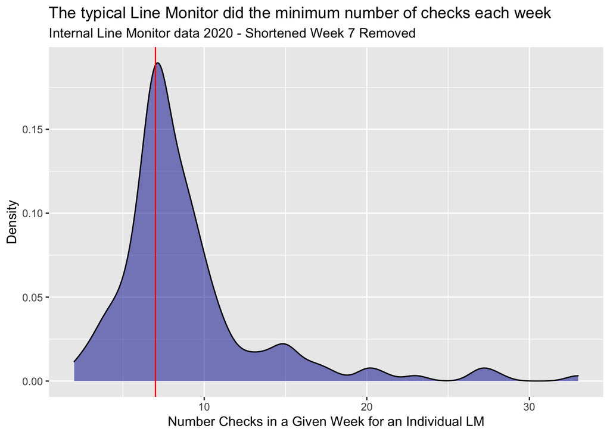

Now, in this plot, it appears that there are some Line Monitors that do significantly more than the minimum amount each week. Those of us who did go above and beyond the expectation were scolded by last year’s leadership because we helped create a “toxic environment” by doing too much. It should be noted that if the four of us who were scolded for going above and beyond had done the median number of checks, there would have been at least 76 fewer checks last year (due to not having enough people to complete the check), which would result in there only being 20 more checks than the “disappointing” 2019 season despite the 2020 tenting season being a longer season.

The Line Monitors will also try to tell you that they still end up doing roughly as much as blue tenters throughout the season, and so it averages out to being the same as tenters. So, I decided to calculate the average amount of time spent in K-Ville for each individual tenter and each individual Line Monitor. Being generous to Line Monitors, I assumed:

- The Line Monitor did 8 checks per week (which is assumed to take 20 minutes to complete, though many times it’s a lot shorter)
- There were 35.5 checks per week (resulting in a total of 35.5 hours of grace time for tenters)
- There was 1 attendance event every week (which is assumed that a Line Monitor attends for an hour every other week)
- There was 1 home Men’s Basketball game per week (resulting in 6 hours of grace time for tenters)
  - For this game, it’s assumed that a Line Monitor spends 2 hours in K-Ville during the day (not including time for checks) for gameday shifts and then 2 additional hours for gameday responsibilities
- There was 1 home Women’s Basketball game per week (resulting in 6 hours of grace time for tenters)
- There was 1 away Men’s Basketball game per week (resulting in 4 hours of grace time for tenters)
- There was 1 away Women’s Basketball game per week (resulting in 4 hours of grace time for tenters)

Here are the results:

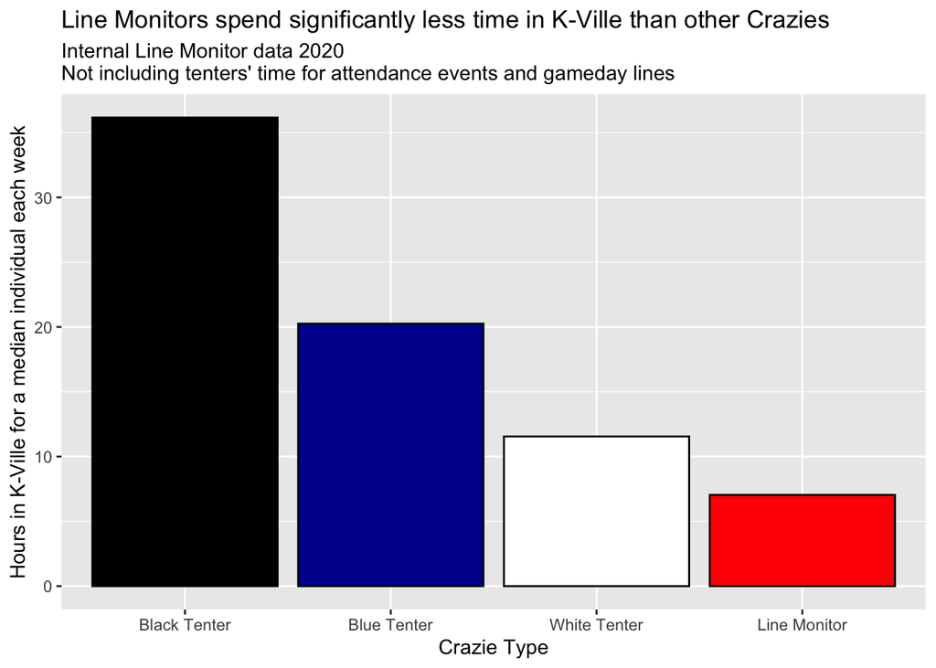

Line Monitors will argue that they do a lot outside of K-Ville. For roughly 7 Line Monitors, this is true. Head Line Monitors, VPs of Tenting, VPs of Gameday Operations, and VP of Internal Affairs do a lot outside of K-Ville. However, they make up less than a quarter of Line Monitors. Line Monitors will argue that everyone else still participates a lot by making dirt sheets, being involved in programming, and helping with technology. This is not the case. In fact, usually it’s those that are already the most involved in the organization that do these tasks. At least two-thirds of the organization does not participate in any of these. Additionally, the amount of time that is spent on these tasks still does not even come close to closing the gap between the time commitment for tenters and for Line Monitors.

### Failure to Fulfill Expectations

One would think that with Line Monitors having their expectations being so low that they would at least be able to fulfill their responsibilities. The internal policy that we all agreed to last year stated that if anyone failed to fulfill any of the expectations mentioned in the previous section, they would receive a strike. Once a Line Monitor received their third strike, they would not be allowed to attend any subsequent game in the season, including the UNC game. The Head Line Monitors were happy to announce that every Line Monitor was able to attend the UNC game. They were definitely not happy to announce everyone’s strike totals.

Below I plotted how many strikes each Line Monitor should have received (strikes deserved) for not fulfilling requirements. In red, you’ll see the amount of strikes they actually received (strikes enforced). The Head Line Monitors were extremely lenient in not enforcing strikes, as they felt bad doing so, so they actively looked for reasons to not give people strikes. You can see below that even still, Line Monitors received more than three enforced strikes and were still allowed to attend the UNC game.

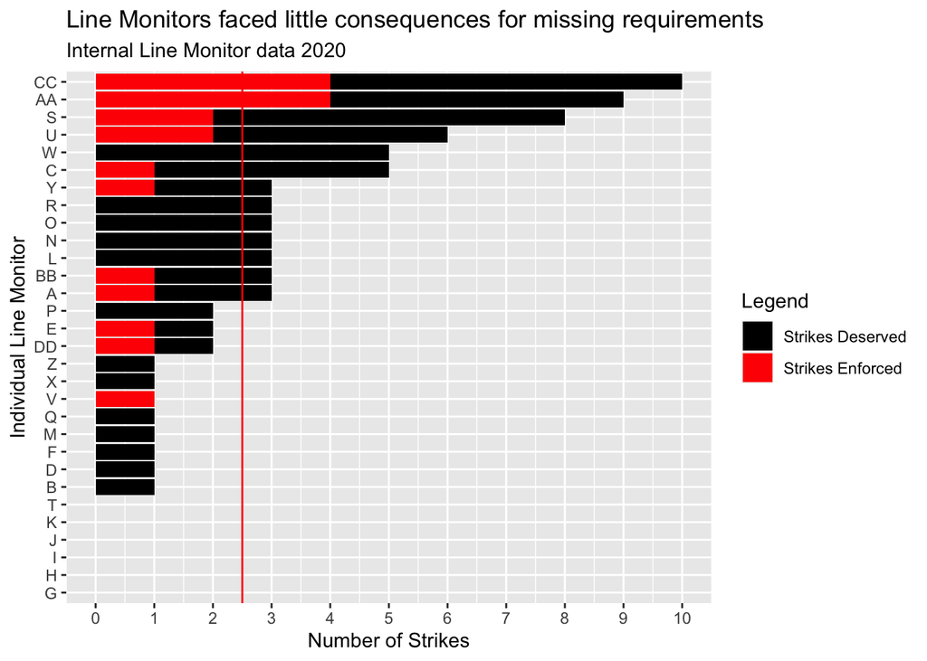

I personally received one strike when I was sick that was not enforced, and I would argue that that is the exact point of having the three-strike rule. A good Line Monitor should only opt to take a strike when they are physically unable to complete their requirements. With that said, nearly half of the entire organization did not do what was necessary to attend the UNC game.

It should not be lost on anyone the irony in bumping tents after their second missed tent check while allowing two Line Monitors with four enforced strikes to attend the UNC game. This is absurd when you consider that a Line Monitor knows exactly what they have to do each week while a tenter has no idea when tent checks will be. This is absurd when you consider that a Line Monitor’s personal requirements are so low while a tenter is supposed to do so much. This is absurd when you consider that a Line Monitor has three strikes while a tenter only has two.

It should also not be lost on anyone the hypocrisy in being flexible on requirements for Line Monitors while being strict on tenters. Tenters have to go through an appeal process to try to explain why they missed a check while the Head Line Monitors look for ways to justify not enforcing a strike, asking the Line Monitor at fault if they had too much homework or were out of town. It’s hard to imagine that a tent could miss 10 tent checks in a season and still be able to attend the UNC game in the first three rows. No Line Monitor should ever receive 10 strikes and still be allowed to attend the UNC game, especially when the requirements are so low to begin with.

Is it truly hard to imagine why tenters do not respect Line Monitors when the Line Monitors don’t even have to do their low-requirement jobs?

### Recruitment

I’ve brought up these concerns in Line Monitor meetings before. And while I’ve included in here already a majority of the counterarguments, there is one that seems to always be presented: why should Line Monitors feel bad? As one Line Monitor put it, no one should feel bad about doing less because “you were chosen for a reason.” This is to say that Line Monitors are supposed to be the craziest of the Crazies, so since you’re a Line Monitor, you’ve already been determined to be Crazie enough, and there’s no reason for you to do more. While one could argue that by doing less than other Crazies, you’re no longer the craziest of the Crazies, let’s instead look at the reason why Line Monitors were chosen.

One would think that choosing Line Monitors would be a very straightforward task. Considering that the process for tenters getting into basketball games is already a meritocracy, it should be easy to see who truly are the craziest of the Crazies. Well, one would think that that could describe the Line Monitors, considering all of the benefits they receive over tenters, including seating, access to the basketball teams and facilities, and knowledge of special events such as the surprise Coach K meeting this past year. However, this is not how Line Monitors decide who joins their team.

Line Monitors treat recruitment like one would treat recruitment for an SLG or Greek organization. As one of the organization’s leaders said this year, “I don’t care if they have a Duke Basketball tattoo. If they’re weird, we’re not taking them.” Line Monitors do not care about how much one goes to games or is committed. Applicants just have to check off the box for being “cool.” There’s no doubt that Line Monitors take into account how they’d feel about you attending their “internal bonding events” during deliberations.

Line Monitors like to base their decisions on what they call “the 2:00 AM test.” In fact, for the second year in a row, one of the organization’s leaders said that it is the most important factor in determining whether or not a candidate should become a Line Monitor. The 2:00 AM test is whether or not one would like to run a 2:00 AM tent check with that candidate. What this amounts to is wondering if this candidate is “cool” or “weird.” Is this candidate someone who’d typically be in your friend group or not? It does not matter how committed this person is to K-Ville. It does not matter how much this person loves Duke Basketball. It does not matter how much this person will contribute to the organization. All that matters is whether or not you would want to hang out with this person.

Now, it’s not unreasonable for Line Monitors to want people that they like to make up their organization. However, it is unreasonable to do so and then believe that they are entitled to more benefits and less work than everyone else while doing so. It’s not surprising that when they only select the candidates they like rather than the candidates that are qualified, there are so many Line Monitors that do not do the work. If Line Monitors wanted to do less work and still somewhat be respected, perhaps they need to change their priorities in recruitment.

### A Proposal

There’s no way around this: there needs to be a restart of the Line Monitor organization. The tasks Line Monitors do need to be done, but there does not have to be a separate organization that keeps their inner-workings secret from the rest of K-Ville. Doing so leads to the lazy, unaccountable organization we see today, which creates the fragmented K-Ville we see today.

Instead, I propose having the Line Monitors actually represent the tenters. Each season, there will be available 6 spots for sophomores, 3 spots for juniors, and 1 spot for a senior in the new Line Monitor organization. These spots will be voted on and filled by anyone who attended the UNC game that previous year. Additionally, these same people will vote for any two of the upcoming seniors for the new Head Line Monitor position. Those two new Head Line Monitors would then select who fills the VP roles, such as VP of Tenting, VP of Gameday Operations, and VP of Internal Affairs.

I know the argument against this is that it becomes a popularity contest, but it at least takes into account commitment to K-Ville- unlike the current process. For example, if someone was committed to K-Ville, they would be in K-Ville a lot and therefore be known in K-Ville. I also think, especially for the Head Line Monitor position, that this will help reflect the views of K-Ville residents more. Right now, just the current Head Line Monitors select the next year’s Head Line Monitors, which means they select candidates that do not want to make necessary changes (especially those that hurt Line Monitors and benefit K-Ville) because, well, why would they? Any change that is made is a spit in the face of their legacy. Even after this year’s poor Line Monitor performance, one of the new Head Line Monitors wrote that they did not want to make any changes to internal policy.

Now, there are many alternative solutions beyond my proposal. I think the best idea would be for there to be a round table discussion on this. However, one thing we can all agree on is that we need to restart the Line Monitor organization in order to fix K-Ville.